# Education and Hygiene: Cornerstones for Child Development

### Limitations of the Analysis:

While this scatter plot provides valuable insights, it is important to note the limitations: - **Outliers**: Some countries may not follow the expected trend due to factors other than income, such as corruption, political instability, or lack of efficient resource allocation. - **Data Gaps**: There may be some missing or incomplete data for certain countries, which can skew the results or limit the interpretation of trends.

Overall, this scatter plot serves as a powerful visual tool to explore the relationship between economic prosperity and hygiene access, highlighting the disparities and areas where further attention is needed to ensure universal access to sanitation facilities.

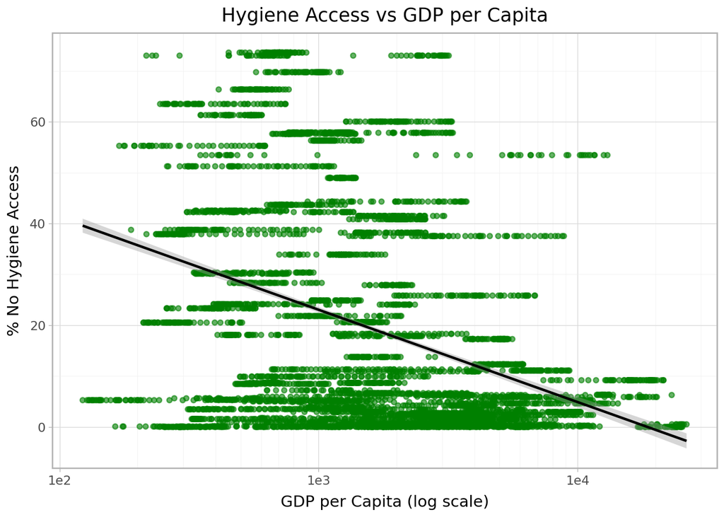

```python
# Prepare data and rename column
merged = pd.merge(latest_hyg, metadata, how='left', on='country')
merged = merged.rename(columns={
    'GDP per capita (constant 2015 US$)': 'gdp_per_capita'
})

# Now use the clean name in plotnine
(p9.ggplot(merged.dropna(subset=['gdp_per_capita']),
           p9.aes(x='gdp_per_capita', y='obs_value')) +
 p9.geom_point(alpha=0.6, color='green') +
 p9.geom_smooth(method='lm', color='black') +
 p9.scale_x_log10() +
 p9.labs(title='Hygiene Access vs GDP per Capita',
        x='GDP per Capita (log scale)', y='% No Hygiene Access') +
 p9.theme_light())
```